# Prior Distributions for Tau and PI

In this script we find reasonable prior distributions based on reported data for the network transmission parameter ($\tau$) and the population prevalence / community transmission parameter ($\pi$).

```r
#library(httr)
#library(jsonlite)
library(zoo)
library(dplyr)
library(ggplot2)
library(fitdistrplus)
library(ggpubr)
```

```r
path.out.figures <- "1_Figures" # Change to where to write output files to
```

# Network Transmission- Tau

We want to estimate a prior distribution for the Secondary attack (infection) rate: https://www.cdc.gov/csels/dsepd/ss1978/lesson3/section2.html

We have two datasets- provided by Lewis et al. 202 and Jing et al. 2020 - that we can use to estimate a prior distribtion for tau.

```r
path.in <- "5_SAR datasets" # Specify folder locatin of inputs
Lewis2020 <- read.csv(file.path(path.in, "Lewis2020.csv"))
Jing2020 <- read.csv(file.path(path.in, "Jing2020.csv"))
```

## Lewis et al 2020:

- 58 households (58 primary infections)
- 32 households had evidence of secondary infection
- SIR was 28% (n=52/188)
- Study of household transmission. Study was conducted March - May 2020 (period in which shelter-in-place orders and social distancing recommendations were largely in place across the US) in Utah and Wisconsin. These states chosen due to relatively low COVID-19 prevalence in order to reduce the risk of additional community exposure to household contacts.

```r
# calculate SIR for entire study population
sum(Lewis2020$any_pos)
```

```
## [1] 110
```

```r
table(Lewis2020$member_type) # member_type =1 is index case; = 0 is household contact
```

```
##
##   0   1
## 188  58
```

```r
new_cases <- sum(Lewis2020$any_pos)- sum(Lewis2020$member_type)
new_cases / (nrow(Lewis2020) - sum(Lewis2020$member_type))
```

```
## [1] 0.2765957
```

```r
# 58 primary infections
# 52 secondary infections (numerator)
# 188 contacts (denominator)
# SIR = 28% (same as found in Lewis 2020 paper)
# SAR = number new cases among contacts / total number of contacts
```

Note: `new_hh_memnum` gives the total number of people in the household However, 9 individuals declined to participate `house_mem_count` gives the number of people in the household who participated We will estimate SAR assuming the total size of the household is given by house_mem_count

```r
# create unique householdid var
Lewis2020$household_id <- gsub("(\\d+)[^-]*$", "", Lewis2020$study_id_merge)
Lewis2020$household_id <- gsub("-", "", Lewis2020$household_id)
```

Estimate a secondary infection rate for each household/cluster in the data set and then fit a distribution to these taus

```r
Lewis_SAR <- Lewis2020 %>%
  group_by(household_id) %>%
  summarise(household_id = household_id,
            secondary = sum(any_pos)-1,
            num_contacts = housemem_count-1,
            SAR = secondary/ num_contacts,
            data_id = "Lewis2020") %>%
            distinct()
```

## Jing et al 2020

```r
# for now, lets just look at household secondary attack rate
Jing2020_house <- Jing2020 %>% filter(Same.Residential.Address == 1)
Jing2020_house$any_pos <- ifelse(Jing2020_house$Case.Type == "primary case" | Jing2020_house$Case.Type == "secondary case",
                                 1, 0)
# 14 times where there is more than one primary case in a cluster
Jing2020_house %>% count(Cluster.ID, Case.Type) %>% summarise(bad = sum(ifelse(Case.Type == "primary case" & n > 1, 1, 0)))
```

```
##   bad
## 1  14
```

```r
# cluster.id where there is more than one primary case
remove_clusters <- Jing2020_house %>% count(Cluster.ID, Case.Type) %>% filter(Case.Type == "primary case" & n > 1) %>% dplyr::select(Cluster.ID)

Jing2020_house2 <- subset(Jing2020_house, !Jing2020_house$Cluster.ID %in% remove_clusters$Cluster.ID)
Jing2020_house2$IsSecondary <- ifelse(Jing2020_house2$Case.Type == "secondary case", 1, 0)

temp <- Jing2020_house2 %>% count(Cluster.ID)
table(temp$n) # 19 clusters that only contain 1 person (primary case)
```

```
##
##  1  2  3  4  5  6  7  8  9 10
## 19 26 36 27 24 20  2  8  1  5
```

```r
# these 19 clusters are dropped (can't infer valid SAR)
length(unique(Jing2020_house2$Cluster.ID)) # 168 clusters total
```

```
## [1] 168
```

```r
Jing_SAR <- Jing2020_house2 %>%
  filter(Case.Type == "secondary case" | Case.Type == "contact") %>%
  group_by(Cluster.ID) %>%
  summarise(household_id = Cluster.ID,
            secondary = sum(IsSecondary),
            num_contacts = Size..Same.Residential.Address.-1,
            SAR = secondary/num_contacts,
            data_id = "Jing2020") %>%
  distinct() # 149 clusters after dropping the 19 that only have 1 person
mean(Jing_SAR$SAR)
```

```
## [1] 0.1780335
```

```r
# SAR = number new cases among contacts / total number of contacts
```

## Fit distribution to data

Merge into one SAR dataset

```r
# keep columns that are same in both data sets
common_col <- c(intersect(names(Jing_SAR), names(Lewis_SAR)))
all_SAR <- rbind(Jing_SAR[,common_col], Lewis_SAR[,common_col])
```

### Beta Binomial Distribution

The beta distribution is the conjugate prior probability distribution to the binomial and is a useful model for the random behavior of a percentage/proportion (since it is defined n the interval [0,1]). Given our observed SAR values (data, $X$) and a beta prior, we want to estimate the parameters (alpha and beta).

Using the parameterization described here, we have closed form solutions for $\alpha$ and $\beta$: https://en.wikipedia.org/wiki/Beta-binomial_distribution#Further_Bayesian_considerations

Let $k_i$ be the number of successes out of $n_i$ trials for event $i$:
$$k_i \sim Bin(n_i, \theta_i) \\
\theta_i \sim Beta(\mu, M), i.i.d$$

To find the point estimates of $\mu$ and $M$ we use the sample:
$$\hat{\mu} = \frac{\sum_{i=1}^N k_i}{\sum_{i=1}^N n_i} \\
s^2 = \frac{1}{N}\sum_{i=1}^N var \left(\frac{k_i}{n_1} \right) \\
\hat{M} = \frac{\hat{\mu}(1-\hat{\mu})-s^2}{s^2 - \frac{\hat{\mu}(1-\hat{\mu}}{N} \sum_{i=1}^N \frac{1}{n_i}}$$

Once we have the point estimates for the underlying distribution, we use them to find a point estimate of $\hat{\theta_i}$, the probability of success for event $i$:
$$\hat{\theta_i} = \frac{k_i + \hat{M}\hat{\mu}}{n_i + \hat{M}}$$

```r
N <- nrow(all_SAR)

# point estimates for mu and M
hat_theta = all_SAR$secondary / all_SAR$num_contacts
mu = sum(all_SAR$secondary)/sum(all_SAR$num_contacts)
s2 = N *  sum(all_SAR$num_contacts * (hat_theta -mu)^2)/((N-1) * sum(all_SAR$num_contacts))
M_hat = (mu * (1-mu) -s2)/(s2 - mu * (1-mu)/N * sum(1/all_SAR$num_contacts))

print(paste("M_hat=", M_hat, "mu=", mu))
```

```
## [1] "M_hat= 3.50062783976831 mu= 0.198830409356725"
```

```r
alpha <- M_hat*mu
beta <- M_hat*(1-mu)
print(paste("alpha=", alpha, "beta=", beta))
```

```
## [1] "alpha= 0.696031266386682 beta= 2.80459657338163"
```

```r
# point estimate for the posterior (probability of success for event i)
theta_i <- (all_SAR$secondary + M_hat*mu)/(all_SAR$num_contacts + M_hat)
all_SAR$theta_i <- theta_i
```

```r
# plot distribution using these parameters
p <- seq(0,1,length=100)
pdf(file.path(path.out.figures, "beta_dist.pdf"), width =8, height =5)
plot(p, dbeta(p, alpha, beta), ylab="density", type ="l", col=7)
legend(0.5,5, c("Be(alpha=0.70, beta=2.80)"),
       lty=c(1,1,1,1),col=c(7,6,5,4,3,2,1))
dev.off()
```

Simulate number of infections using fitted distribution, compare to observed

```r
B <- 1000
mock <- sapply(1:B, function(b){
  u = sapply(all_SAR$num_contacts, function(x){rbinom(1,x,all_SAR$theta_i)/x})
  o = ks.test(u, all_SAR$SAR)
  return(o$p.value)
})
```

[output not shown]

[output cut: 2944 more lines]

[output not shown]

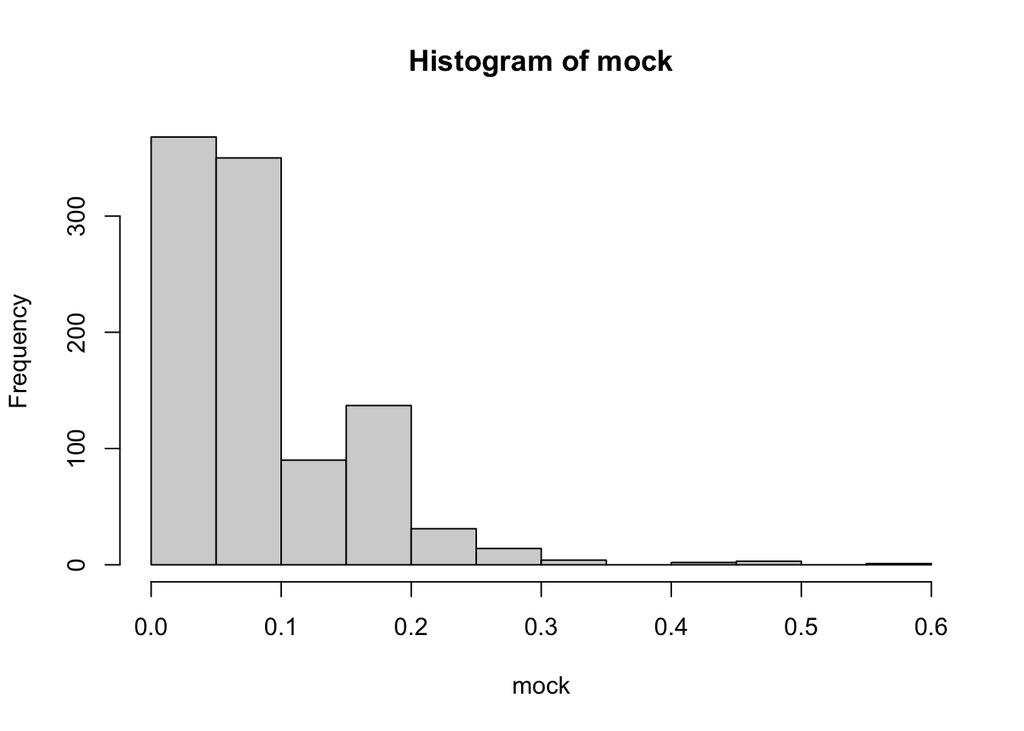

```r
hist(mock)
```

```r
# just to visualize- not a formal test
sim_dist <- lapply(all_SAR$num_contacts, function(x){rbinom(100,x,all_SAR$theta_i)})
sim_dist <- data.frame(x=unlist(sim_dist))

pdf(file.path(path.out.figures, "fitted_tau_dist.pdf"), width =8, height =5)
ggplot()+
  geom_density(data=sim_dist, aes(x=x), alpha=0.3, fill="red")+
  geom_density(data=all_SAR, aes(x=secondary), alpha=0.3, fill="green")+
  ggtitle("Simulated Secondary Cases vs. Observed")
dev.off()
```

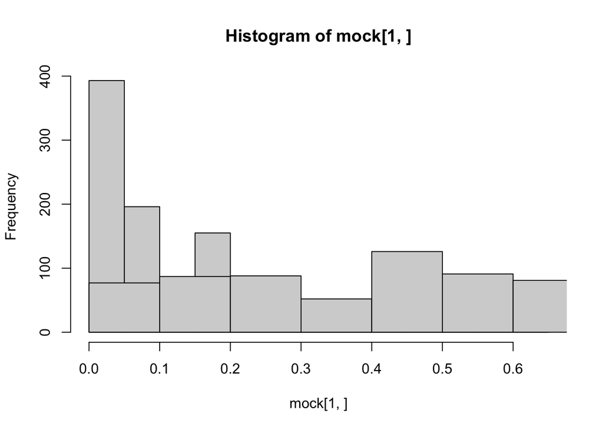

```r
##### Check goodness of fit
mock <- sapply(1:B, function(b){
  u = sapply(all_SAR$num_contacts, function(x){rbinom(1,x,0.199)/x}) + rnorm(length(all_SAR$num_contacts), 0, 0.001)
  #m = as.matrix(rbind(as.numeric(names(table(u))), table(u)))
  v = sapply(all_SAR$num_contacts, function(x){rbinom(1,x,0.199)/x})+ rnorm(length(all_SAR$num_contacts), 0, 0.001)
  #mm = as.matrix(rbind(as.numeric(names(table(v))), table(v)))
  o = ks.test(u, all_SAR$secondary/all_SAR$num_contacts + rnorm(length(all_SAR$num_contacts), 0, 0.001))
  oo = ks.test(u, v, )
  return(c(o$p.value, oo$p.value))
})
hist(mock[1,])
hist(mock[2,], alpha=0.5,add=TRUE)
```

```r
mean(mock[2,] < mean(mock[1,]))
```

```
## [1] 0.077
```

## Alpha, Beta Parameters from published CI

The previously estimated $\alpha$ and $\beta$ parameters are for household transmission, based on data from two studies. However, estimates of SAR in the literature are heterogeneous and other settings (non-household) may have different SAR distributions. Therefore, we use the point estimates and 95 percent confidence intervals from published literature to estimate the $\alpha, \beta$ parameters of a Beta distribution for that data. To do so we use a function developed in the Division of Clinical Epidemiology at Montreal General Hospital, http://www.medicine.mcgill.ca/epidemiology/Joseph/PBelisle/BetaParmsFromQuantiles.html

```r
library(tidyverse)
```

```r
source("beta_params.R")
sar_dat <- read.csv(file.path(path.in, "SAR_95CI_sc_collected.csv"))
sar_dat$alpha <- numeric(nrow(sar_dat))
sar_dat$beta <- numeric(nrow(sar_dat))

for (i in 1:nrow(sar_dat)){
  q <- c(sar_dat[i, "X95CI_lw"], sar_dat[i, "X95CI_up"])
  q[1] <- ifelse(q[1]==0, q[1]+0.0001, q[1]) # lower bound can't be exactly zero
  beta <- beta.parms.from.quantiles(q=q)
  sar_dat[i,"alpha"] <- beta$a
  sar_dat[i, "beta"] <- beta$b
}

# add alpha and beta that we calculated from Jing and Lewis data
# "alpha= 0.696031266386682 beta= 2.80459657338163"
sar_dat[nrow(sar_dat)+1,] <- c("LewisJing_2020", "Household", "NA", "NA", "NA", "sc_calculated",
                               0.696, 2.805)
sar_dat$alpha <- as.numeric(sar_dat$alpha)
sar_dat$beta <- as.numeric(sar_dat$beta)
sar_dat$alpha_beta <- paste(round(sar_dat$alpha, 2), ",", round(sar_dat$beta, 2))

# generate the beta distributions with different parameters
set.seed(123) # reproducible
p <- seq(0, 1, .01)
beta_dist <- matrix(nrow = length(p), ncol = nrow(sar_dat)+1)
beta_dist[,1] <- p
for(i in 1:nrow(sar_dat)){
  beta_dist[,(i+1)] <- dbeta(p, sar_dat[i, "alpha"], sar_dat[i, "beta"])
}
beta_dist <- data.frame(beta_dist)
colnames(beta_dist) <- c("p", sar_dat$alpha_beta)
beta_dist_long <- gather(beta_dist, alpha_beta, dens, "0.45 , 2.38":"0.7 , 2.81", factor_key = TRUE)

pdf(file.path(path.out.figures, "pi_prior_all.pdf"),width=8, height=5)
ggplot(beta_dist_long, aes(x=p, y = dens, group = alpha_beta))+
  geom_line(aes(color = alpha_beta)) +
  ggtitle("Beta Priors on Population Prevalence")
dev.off()
```

# Prevalence - Pi

## Alpha, Beta Parameters from published CI

Again, we use a function developed in the Division of Clinical Epidemiology at Montreal General Hospital, http://www.medicine.mcgill.ca/epidemiology/Joseph/PBelisle/BetaParmsFromQuantiles.html

```r
source("beta_params.R")
```

```r
covidestim <- read.csv(file.path(path.in, "prevalence_covidestim.csv"))
state_pops <- read.csv(file.path(path.in, "state_populations.csv"))
state_pops <- state_pops %>% dplyr::select(NAME, POPESTIMATE2019)
# Only keep data where confidence interval provided
covidestim <- covidestim %>% drop_na(cases.fitted.hi, cases.fitted.lo)
covidestim$date <- as.Date(covidestim$date)
# select 1 representative state from each geographic divsion defined by U.S. census Bureau
# choose first state alphabetically in the Division if multiple available
# continental US only
# Region 1: Northeast, Division 1: Maine, Division 2: none available
# Region 2: Midwest, Division 3: Wisconsin, Div 4: Iowa
# Region 3: South, Div 5: Georgia, Div 6: Alabama, Div 7: Arkansas
# Region 4: West, Div 8: Idaho, Div 9: Oregon
table(covidestim$state)
```

```
##
##        Alabama         Alaska       Arkansas        Georgia         Hawaii
##            473            474            474            476            476
##          Idaho           Iowa         Kansas       Kentucky      Louisiana
##            473            474            474            474            473
##          Maine      Minnesota    Mississippi       Missouri        Montana
##            473            474            473            473            473
##       Nebraska         Nevada  New Hampshire     New Mexico North Carolina
##            494            475            476            475            476
##   North Dakota       Oklahoma         Oregon    Puerto Rico   South Dakota
##            473            473            476            436            473
##      Tennessee           Utah        Vermont     Washington  West Virginia
##            475            473            477            527            474
##      Wisconsin        Wyoming
##            477            479
```

```r
states <- c("Maine", "Wisconsin", "Iowa", "Georgia", "Alabama", "Arkansas", "Idaho", "Oregon")
pi_states <- covidestim %>% filter(state %in% states)

table(pi_states$state)
```

```
##
##   Alabama  Arkansas   Georgia     Idaho      Iowa     Maine    Oregon Wisconsin
##       473       474       476       473       474       473       476       477
```

```r
# left join (kep everything in left df, only matching from right df)
pi_states <- left_join(pi_states, state_pops,
              by = c("state" = "NAME"))

pi_states <- pi_states %>%
  dplyr::mutate(year_month = as.yearmon(date),
                infections = infections/POPESTIMATE2019, # normalize by size of population
                infections.hi = infections.hi/POPESTIMATE2019,
                infections.lo = infections.lo/POPESTIMATE2019,
                infections_10dsum = zoo::rollapply(infections, # cumulative 10 day rolling, estimate of active cases
                                                   width=10,
                                                   FUN=function(x) sum(x, na.rm=FALSE),
                                                   align="right", fill=NA),
                infections_10dsum_hi = zoo::rollapply(infections.hi,
                                                   width=10,
                                                   FUN=function(x) sum(x, na.rm=FALSE),
                                                   align="right", fill=NA),
                infections_10dsum_lo = zoo::rollapply(infections.lo,
                                                   width=10,
                                                   FUN=function(x) sum(x, na.rm=FALSE),
                                                   align="right", fill=NA),
  )

pi_dat <- pi_states %>%
  group_by(year_month, state) %>%
  summarise(infections_month_avg = mean(infections_10dsum),
            infections_month_avg.hi = mean(infections_10dsum_hi),
            infections_month_avg.lo = mean(infections_10dsum_lo)) %>%
  drop_na(infections_month_avg)
pi_dat <- data.frame(pi_dat)
```

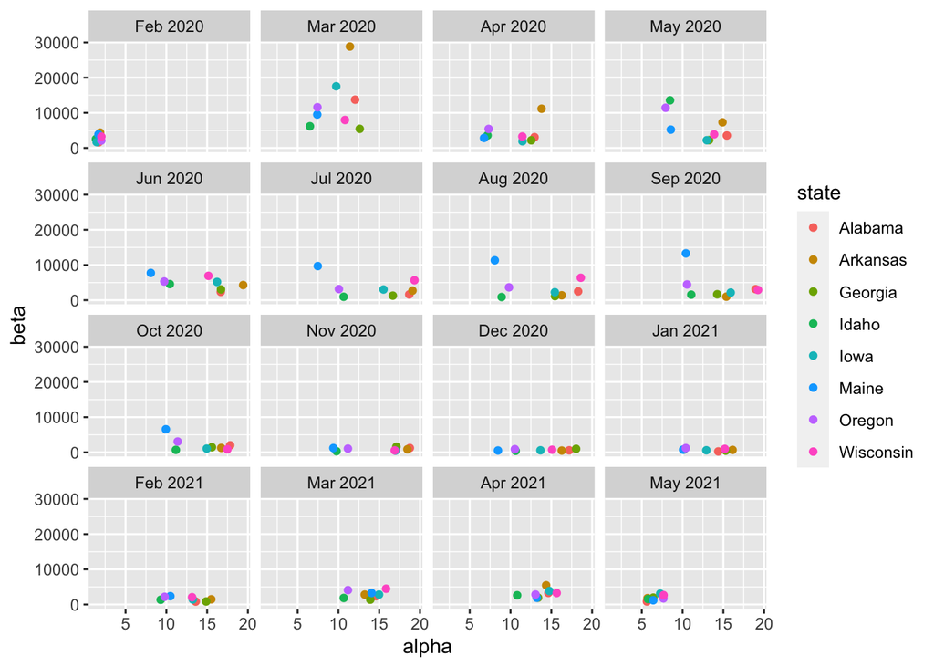

```r
pi_dat$alpha <- numeric(nrow(pi_dat))
pi_dat$beta <- numeric(nrow(pi_dat))

for (i in 1:nrow(pi_dat)){
  q <- c(pi_dat[i, "infections_month_avg.lo"], pi_dat[i, "infections_month_avg.hi"])
  q[1] <- ifelse(q[1]==0, q[1]+0.0001, q[1]) # lower bound can't be exactly zero
  beta <- beta.parms.from.quantiles(q=q)
  pi_dat[i,"alpha"] <- beta$a
  pi_dat[i, "beta"] <- beta$b
}

pi_dat$alpha <- as.numeric(pi_dat$alpha)
pi_dat$beta <- as.numeric(pi_dat$beta)
pi_dat$alpha_beta <- paste(round(pi_dat$alpha, 2), ",", round(pi_dat$beta, 2))
pi_dat$state_date <- paste(pi_dat$state, pi_dat$year_month)

ggplot(pi_dat, aes(x = alpha, y = beta)) +
  geom_point(aes(color=state)) +
  facet_wrap(~factor(year_month))
```

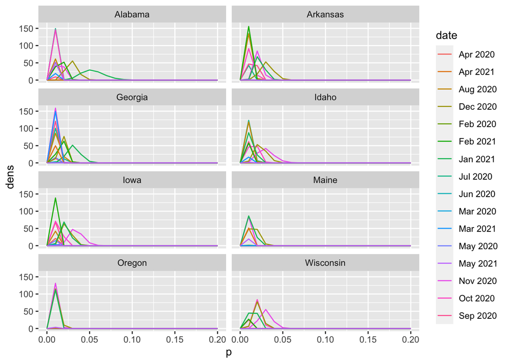

```r
# generate the beta distributions with different parameters
set.seed(123) # reproducible
p <- seq(0, 1, .01)
beta_dist <- matrix(nrow = length(p), ncol = nrow(pi_dat)+1)
beta_dist[,1] <- p
for(i in 1:nrow(pi_dat)){
  beta_dist[,(i+1)] <- dbeta(p, pi_dat[i, "alpha"], pi_dat[i, "beta"])
}
beta_dist <- data.frame(beta_dist)
colnames(beta_dist) <- c("p", pi_dat$state_date)
beta_dist_long <- gather(beta_dist, state_date, dens, 2:128, factor_key = TRUE)
beta_dist_long$state <- gsub("([A-Za-z]+).*", "\\1", beta_dist_long$state_date)
beta_dist_long$date <- gsub("^[^ ]+ ", "", beta_dist_long$state_date)

ggplot(beta_dist_long, aes(x=p, y = dens, group = state_date))+
  geom_line(aes(color = date)) +
  facet_wrap(~state, ncol = 2)+
  xlim(0, .2) +
  theme(legend.position = "right")
```

We could use data by age, however results do not appear to be significnatly different and the geographic data are more detailed:

```r
# pi_dat <- read.csv(file.path(path.in, "infection_rate_cdc.csv"))
# pi_dat$alpha <- numeric(nrow(sar_dat))
# pi_dat$beta <- numeric(nrow(sar_dat))
# pi_dat$infection_pct <- pi_dat$infection_hundredths/100000 #percentage of population
# pi_dat$cilw_pct <- pi_dat$X95CI_lw/100000
# pi_dat$ciup_pct <- pi_dat$X95CI_up/100000
# pi_dat$infection_pct_7day <- pi_dat$infection_pct/26 # average over number of weeks in data
# pi_dat$cilw_pct_7day <- pi_dat$cilw_pct/26
# pi_dat$ciup_pct_7day <- pi_dat$ciup_pct/26
#
# for (i in 1:nrow(pi_dat)){
#   q <- c(pi_dat[i, "cilw_pct_7day"], pi_dat[i, "ciup_pct_7day"])
#   q[1] <- ifelse(q[1]==0, q[1]+0.0001, q[1]) # lower bound can't be exactly zero
#   beta <- beta.parms.from.quantiles(q=q)
#   pi_dat[i,"alpha"] <- beta$a
#   pi_dat[i, "beta"] <- beta$b
# }
#
# pi_dat$alpha <- as.numeric(pi_dat$alpha)
# pi_dat$beta <- as.numeric(pi_dat$beta)
# pi_dat$alpha_beta <- paste(round(pi_dat$alpha, 2), ",", round(pi_dat$beta, 2))
#
# # generate the beta distributions with different parameters
# set.seed(123) # reproducible
# p <- seq(0, 1, .01)
# beta_dist <- matrix(nrow = length(p), ncol = nrow(pi_dat)+1)
# beta_dist[,1] <- p
# for(i in 1:nrow(pi_dat)){
#   beta_dist[,(i+1)] <- dbeta(p, pi_dat[i, "alpha"], pi_dat[i, "beta"])
# }
# beta_dist <- data.frame(beta_dist)
# colnames(beta_dist) <- c("p", pi_dat$Age_Group)
# beta_dist_long <- gather(beta_dist, alpha_beta, dens, "0_4":"all_ages", factor_key = TRUE)
#
# ggplot(beta_dist_long, aes(x=p, y = dens, group = alpha_beta))+
#   geom_line(aes(color = alpha_beta)) +
#   xlim(0, .2)
```